# Advanced Regression Analysis - GOVT 6029: Problem Set 1 Solutions

Sergio I Garica-Rios / Claire Leavitt

Feb 15, 2018

## Problems

For all the tables and graphs I’ll be using very minimal code so I am not adding labels, legends, or formatting the tables. As the semester goes we will keep adding formatting options to improve our reports.

1. **Initial set up**
- Load the Democracy dataset into memory as a dataframe. Use the `read.csv` function, and the `stringsAsFactors = FALSE` option. Note that missing values are indicated by “`.`” in the data. Find the option in `read.csv` that controls the string used to indicate missing values.
- Several options, I show two here:
  - Directly from the web

  ```r
  df <-
    read.csv("https://raw.githubusercontent.com/GarciaRios/govt_6029/master/data/democracy.csv",
                 na.strings = ".")
  ```

  - Or after dwonload, which I think you might end up using more frequently

  ```r
  df <- read.csv("democracy.csv", na.strings = ".")
  ```

2. **Initial data exploration**
- Report summary statistics (means and medians, at least) for all variables.
  - The easiest way is to just call a summary of all the variables

  ```r
  summary(df)
  ```

- Create a histogram for political liberties in which each unique value of the variable is in its own bin.

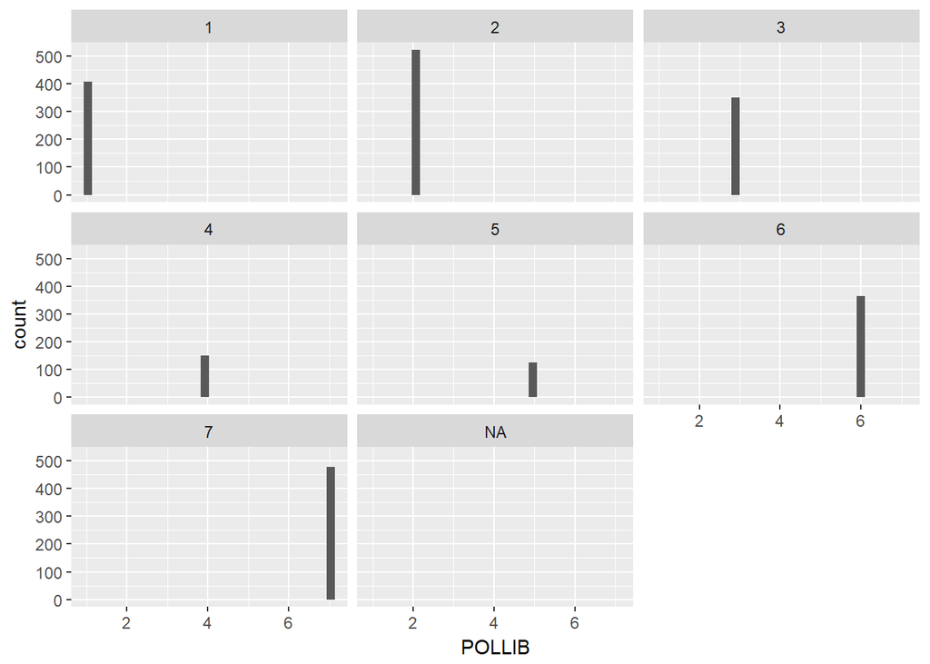

```r
  ggplot(df, aes(POLLIB)) +
    geom_histogram() +
facet_wrap(~POLLIB)
```

- Create a histogram for GDP per capita.

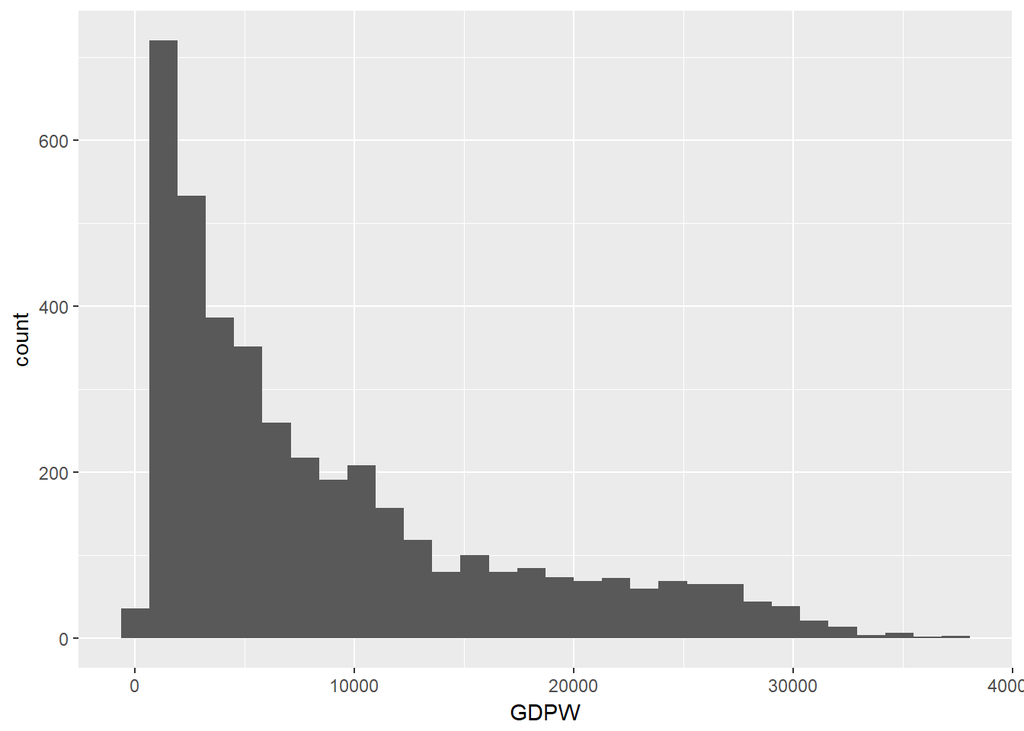

```r
ggplot(df, aes(GDPW)) +
  geom_histogram()
```

- Create a histogram for **log** GDP per-capita. How is this histogram different than the one for GDP per capita when it was not logged.
  - You can transform the variable inside the `aes`.

  ```r
  ggplot(df, aes(log10(GDPW))) +
    geom_histogram()
  ```

  - Or the scale in the plot using `scale_x_log10()`.

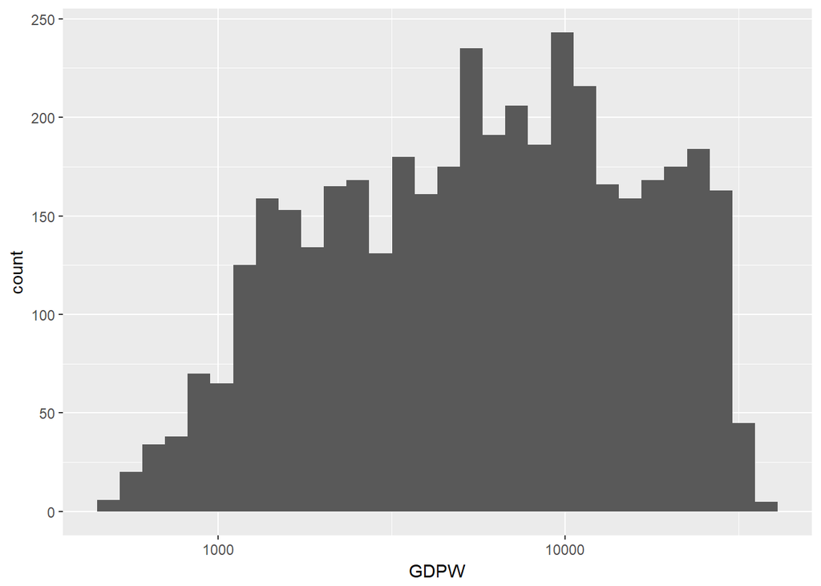

  ```r
  ggplot(df, aes(GDPW)) +
    geom_histogram() +
    scale_x_log10()
  ```

3. **Explore relationships**
- Create a scatterplot of political liberties against GDP per capita.

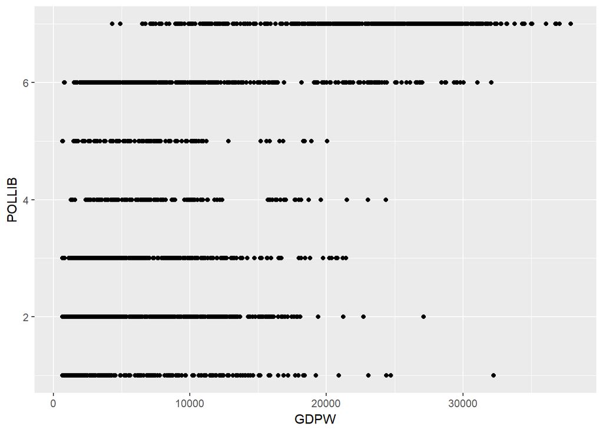

```r
ggplot(df, aes(GDPW,  POLLIB )) +
  geom_point()
```

- When there is a lot of overlap in a scatter plot it is useful to “jitter” the points (randomly move them up and down). Make the previous plot but jitter the points to mitigate the problem of overplotting. (Only jitter the points vertically). You can use `geom_jitter` in **ggplot2** for this.
  - You can put it inside `geom_point` as way to specify the position with `position = position_jitter()`

  ```r
  ggplot(df, aes(GDPW,  POLLIB )) +
    geom_point(position = position_jitter())
  ```

  - Or you can use `geom_jitter`. Both should produce the same results.
    - Notice that I am using some level of trasparency using `alpha` to hihglight those places hwere there is still overlap.
    - In this plot, for instance, we still see a high level of overlap for countries with low level of GDPW wich indicates that it might be better to *log* this variable

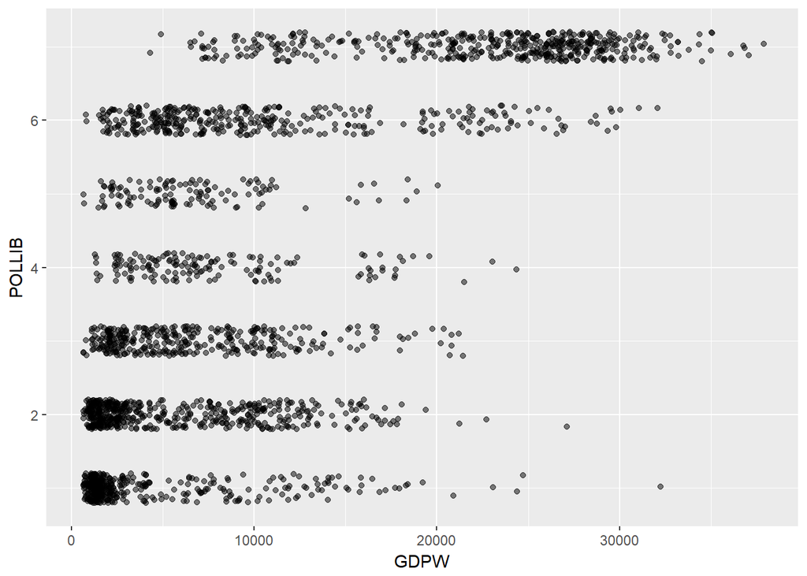

  ```r
  ggplot(df, aes(GDPW,  POLLIB )) +
    geom_jitter(height = .20, alpha = .5)
  ```

- Create a scatterplot of political liberties against **log** GDP per capita. Jitter the points. How is the relationship different than when GDP per capita was not logged.

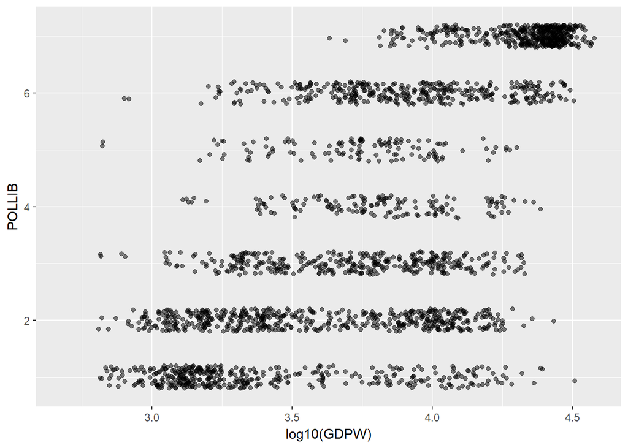

```r
ggplot(df, aes(log10(GDPW),  POLLIB )) +
  geom_jitter(height = .20, alpha = .5)
```

- Create a boxplot of GDP per capita for oil producing and non-oil producing nations.
  - You probably noticed that plugging in `OIL` in the *x* axis produces something like this:

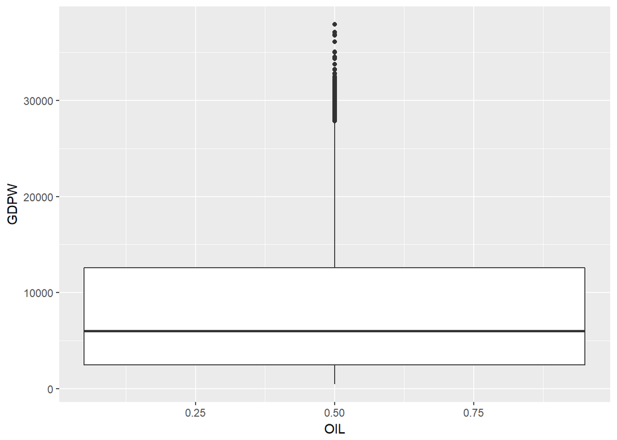

  ```r
  ggplot(df, aes(y = GDPW, x = OIL)) +
       geom_boxplot()
  ```

  - Why is this happenig? If you look at the strucuture of the data you will notice that `OIL` is an integer.

  ```r
  str(df)
  ```

  ```
  ## 'data.frame':    4126 obs. of  16 variables:
  ##  $ COUNTRY: int  1 1 1 1 1 1 1 1 1 1 ...
  ##  $ CTYNAME: Factor w/ 134 levels "Algeria","Angola",..: 1 1 1 1 1 1 1 1 1 1 ...
  ##  $ REGION : Factor w/ 6 levels "Africa","Asia",..: 1 1 1 1 1 1 1 1 1 1 ...
  ##  $ YEAR   : int  1962 1963 1964 1965 1966 1967 1968 1969 1970 1971 ...
  ##  $ BRITCOL: int  0 0 0 0 0 0 0 0 0 0 ...
  ##  $ CATH   : num  0.5 0.5 0.5 0.5 0.5 0.5 0.5 0.5 0.5 0.5 ...
  ##  $ CIVLIB : int  NA NA NA NA NA NA NA NA NA NA ...
  ##  $ EDT    : num  1.16 1.25 1.34 1.45 1.56 ...
  ##  $ ELF60  : num  0.43 0.43 0.43 0.43 0.43 0.43 0.43 0.43 0.43 0.43 ...
  ##  $ GDPW   : int  5012 6083 6502 6620 6612 6982 7848 8378 8536 7816 ...
  ##  $ MOSLEM : num  99.1 99.1 99.1 99.1 99.1 ...
  ##  $ NEWC   : int  1 1 1 1 1 1 1 1 1 1 ...
  ##  $ OIL    : int  1 1 1 1 1 1 1 1 1 1 ...
  ##  $ POLLIB : int  NA NA NA NA NA NA NA NA NA NA ...
  ##  $ REG    : int  0 0 0 0 0 0 0 0 0 0 ...
  ##  $ STRA   : int  0 0 0 0 0 0 0 0 0 0 ...
  ```

  - You can also just ask R the class for that variable.

  ```r
  class(df$OIL)
  ```

  ```
  ## [1] "integer"
  ```

  - So R doesn’t know that *0* and *1* are categorially distinct. Categorical variables in R are called *factors* so let’s tell ggplot that `OIL` should be treated as a *factor*.

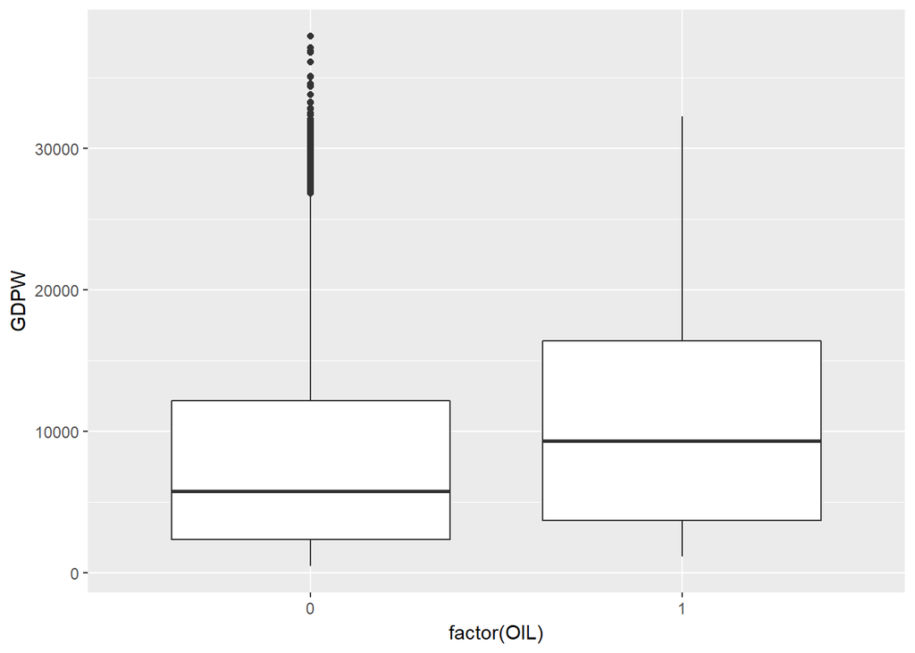

  ```r
  ggplot(df, aes(y = GDPW, x = factor(OIL))) +
       geom_boxplot()
  ```

4. **Transform data and analyse**
- Calculate the mean GDP per capita in countries with at least 40 percent Catholics. How does it compare to mean GDP per capita for all countries?

  ```r
  df %>% filter(ELF60 < .60) %>%
    summarise(mean(GDPW))

  df %>% filter(ELF60 > .60) %>%
    summarise(mean(GDPW))

  df %>% filter(is.na(ELF60)) %>%
    summarise(mean(GDPW))
  ```

  - You can also use `mutate` with `ifelse` statements to create a variable and then `group_by` to separate the results by conditions

  ```r
  df %>%
    mutate(elf3cat = ifelse(ELF60 < .60, "less",
                        "more")) %>%
    group_by(elf3cat) %>%
    summarise(mean(GDPW))
  ```

  ```
  ## # A tibble: 3 x 2
  ##   elf3cat `mean(GDPW)`
  ##     <chr>        <dbl>
  ## 1    less    11803.780
  ## 2    more     3590.939
  ## 3    <NA>     7767.245
  ```

  - Finally, a similar mehtod, and my choice, would be use `case_when` instead of the the *if* statements. I find this method much mote intutitive.

  ```r
    df %>%
    mutate(elf3cat = case_when(ELF60 < .60 ~ "less",
                               ELF60 > .60 ~ "more")) %>%
    group_by(elf3cat) %>%
    summarise(mean(GDPW))
  ```

  ```
  ## # A tibble: 3 x 2
  ##   elf3cat `mean(GDPW)`
  ##     <chr>        <dbl>
  ## 1    less    11803.780
  ## 2    more     3590.939
  ## 3    <NA>     7767.245
  ```

  - Or even soemeting like this:

  ```r
  df %>%
    mutate(ELF_3_cat = case_when(ELF60 < .60 ~ "less",
                           ELF60 > .60 ~ "more",
                           is.na(ELF60) ~ "missing")) %>%
    group_by(ELF_3_cat) %>%
    summarise(Mean = mean(GDPW))
  ```

  ```
  ## # A tibble: 3 x 2
  ##   ELF_3_cat      Mean
  ##       <chr>     <dbl>
  ## 1      less 11803.780
  ## 2   missing  7767.245
  ## 3      more  3590.939
  ```

- What was the median of the average years of education in 1985 for all countries?
  - we can just use `summary`

  ```r
  summary(df$EDT)
  ```

  - Or ask for the specific varibale

  ```r
  df %>%
    filter(YEAR == 1985) %>%
    summarise(Median_EDT= median(EDT, na.rm = T))
  ```

  ```
  ##   Median_EDT
  ## 1      5.625
  ```

  - **Answer:**
    - $Median(EDT)$ in $1985 = 5.62$
- Which country was (or countries were) closest to the median years of education in 1985 among all countries?

  ```r
  df %>%
    filter(YEAR == 1985, EDT>5&EDT<6.5) %>%
    select(EDT, CTYNAME) %>%
    arrange(EDT)
  ```

  ```
  ##         EDT                  CTYNAME
  ## 1  5.055000               Madagasgar
  ## 2  5.095000                Nicaragua
  ## 3  5.150000                    Egypt
  ## 4  5.210000                 Colombia
  ## 5  5.320000                Swaziland
  ## 6  5.375000                  Bolivia
  ## 7  5.425000 China, People's Republic
  ## 8  5.520000                  Lesotho
  ## 9  5.625000                Venezuela
  ## 10 5.725000              El Salvador
  ## 11 5.995000                 Thailand
  ## 12 6.150000       Dominican Republic
  ## 13 6.265000                   Mexico
  ## 14 6.275001                    Syria
  ## 15 6.405000                 Portugal
  ```

  - Venezuela is the median. Lesotho and China are below the median; El Salvador and Thailand right above the median in 1985
- What was the median of the average years of education in 1985 for democracies?

  ```r
  df %>%
    filter(YEAR == 1985, REG == 1) %>%
    summarise(medianEDT = median(EDT, na.rm = T))
  ```

  ```
  ##   medianEDT
  ## 1     7.805
  ```

  - **Answer:**
    - $Median(EDT|Democracy)$ in $1985 = 7.8$
- Which democracy was (or democracies were) closest to the median years of education in 1985 among all democracies?

  ```r
  df %>%
    filter(YEAR == 1985, REG == 1, EDT>7&EDT<9) %>%
    select(EDT, CTYNAME) %>%
    arrange(EDT)
  ```

  ```
  ##      EDT           CTYNAME
  ## 1  7.195             Spain
  ## 2  7.250              Peru
  ## 3  7.280           Austria
  ## 4  7.390             Italy
  ## 5  7.485            Greece
  ## 6  7.805         Mauritius
  ## 7  7.910            France
  ## 8  8.210 Trinidad & Tobago
  ## 9  8.969           Denmark
  ## 10 8.975             Malta
  ```

- Mauritius is the median. Greece and Italy are right below the median; France and Trinidad & Tobago are above the median
- What were the 25th and 75th percentiles of ethnolinguistic fractionalization for new and old countries?

  ```r
  df %>%
    group_by(NEWC) %>%
    summarise(Pct25 = quantile(ELF60, probs = .25, na.rm = T),
          Pct75 = quantile(ELF60, probs = .75, na.rm = T))
  ```

  ```
  ## # A tibble: 2 x 3
  ##    NEWC Pct25 Pct75
  ##   <int> <dbl> <dbl>
  ## 1     0  0.06  0.44
  ## 2     1  0.42  0.75
  ```

As a side, I want to introduce the package `pander` which helps you stylize the tables in Rmarkdown. We will be trying to improve the reports as we go and this is good way to get nicer tables

```r
df %>%
  group_by(NEWC) %>%
  summarise(`25%` = quantile(ELF60, probs = .25, na.rm = T),
            `75%` = quantile(ELF60, probs = .75, na.rm = T)) %>%
  pander()
```

| NEWC | 25% | 75% |
| --- | --- | --- |
| 0 | 0.06 | 0.44 |
| 1 | 0.42 | 0.75 |

Notes:

<sup>1</sup> Przeworski, Adam, Michael E. Alvarez, Jose Antonio Cheibub, and Fernando Limongi. 2000. *Democracy and Development: Political Institutions and Well-Being in the World, 1950-1990*. Cambridge University Press.